# Supervised Learning with Text I

3/7/2018

## From last time…

1. Learned how to acquire text data using APIs.
2. Learned how to clean and prepare text data for analysis.
3. Built a document-term matrix.

## For today

1. **Further text processing** - Sparsity Reduction, TF-IDF Matrix
2. **Building supervised machine learning classifiers with text data** - Naive Bayes.
3. **Assessing the performance of classifiers.**

## Building a pipeline

```r
text_cleaner<-function(corpus){
  tempcorpus = lapply(corpus, function(t) t$getText())
  tempcorpus = lapply(tempcorpus, tolower)
  tempcorpus<-Corpus(VectorSource(tempcorpus))
  tempcorpus<-tm_map(tempcorpus,
                    removePunctuation)
  tempcorpus<-tm_map(tempcorpus,
                    stripWhitespace)
  tempcorpus<-tm_map(tempcorpus,
                    removeNumbers)
  tempcorpus<-tm_map(tempcorpus,
                     removeWords, stopwords("english"))
  tempcorpus<-tm_map(tempcorpus,
                    stemDocument)
  return(tempcorpus)
}
```

## Building a document-term matrix

- Need to go from texts \(\rightarrow\) numbers.
- If \(d =\) documents in a corpus and \(w=\) words in a corpus.
- Create a matrix \(\Delta \in \mathbb{N}^{dXw}\).
- Rows are *documents*, columns are *words*
- This is called the **document-term matrix**.

## Building the document-term matrix

```r
inspect(dtm[1:5, 1:5])
```

```
## <<DocumentTermMatrix (documents: 5, terms: 5)>>
## Non-/sparse entries: 5/20
## Sparsity           : 80%
## Maximal term length: 7
## Weighting          : term frequency (tf)
## Sample             :
##     Terms
## Docs comment discuss fact far heard
##    1       1       1    1   1     1
##    2       0       0    0   0     0
##    3       0       0    0   0     0
##    4       0       0    0   0     0
##    5       0       0    0   0     0
```

## Building the document-term matrix

```r
newcorpus[[2]]$content
```

```
## [1] "done even better elect possibl winner base popular vote campaign differ"
```

## Sparse Document Term Matrices

- **sparse matrix** In numerical analysis a sparse matrix is a matrix in which most of the elements are zero.
- **dense matrix** is a matrix in which most of the elements are nonzero.
- Matrices in text analysis problems tend to be very sparse.
- This implies that they have many parameters that are uninformative.

## Sparsity reduction

```r
dtm<-removeSparseTerms(dtm,0.99)
dtm
```

```
## <<DocumentTermMatrix (documents: 31175, terms: 139)>>
## Non-/sparse entries: 107376/4225949
## Sparsity           : 98%
## Maximal term length: 21
## Weighting          : term frequency (tf)
```

## TF-IDF: Term-Frequency, Inverse Document Frequency

- The document term matrix only contains the counts of each word in each document.
- This is not the most informative measure of how important a word is in a document.
- We can construct a much better measure by weighting the term frequncies by a metric of how *important* a term is.

## TF-IDF: Term-Frequency, Inverse Document Frequency

**Term frequency**- number of times term *t* appears in document *d*

\[TF_{i,j} = \frac{\sum_{i=1}^{w_{d}}1(w_{i} = t)}{w_{d}}\] **Inverse document frequency** - measures importance of a term in a corpus. It is the log of the number of total documents *N* divided by total documents containing the term *t*

\[IDF_{i,j} = ln\left(\frac{N}{\sum_{j=1}^{N}1(d_{j} = t)}\right)\]

## TF-IDF Matrix

\[TF-IDF_{i,j}=TF_{i,j}~X~IDF_{i,j} \] \[TF-IDF \in \mathbb{R}^{dxw}\]

## TF-IDF Matrix

```r
dtm <- DocumentTermMatrix(newcorpus, control = list(weighting = weightTfIdf))
dtm = removeSparseTerms(dtm, 0.95)
inspect(dtm[1:5,4:8])
```

```
## <<DocumentTermMatrix (documents: 5, terms: 5)>>
## Non-/sparse entries: 0/25
## Sparsity           : 100%
## Maximal term length: 6
## Weighting          : term frequency - inverse document frequency (normalized) (tf-idf)
## Sample             :
##     Terms
## Docs donald just thank trump will
##    1      0    0     0     0    0
##    2      0    0     0     0    0
##    3      0    0     0     0    0
##    4      0    0     0     0    0
##    5      0    0     0     0    0
```

- We can easily construct this in **R**

## TF-IDF Matrix

```r
inspect(dtm[1:5,4:8])
```

```
## <<DocumentTermMatrix (documents: 5, terms: 5)>>
## Non-/sparse entries: 0/25
## Sparsity           : 100%
## Maximal term length: 6
## Weighting          : term frequency - inverse document frequency (normalized) (tf-idf)
## Sample             :
##     Terms
## Docs donald just thank trump will
##    1      0    0     0     0    0
##    2      0    0     0     0    0
##    3      0    0     0     0    0
##    4      0    0     0     0    0
##    5      0    0     0     0    0
```

- We can easily construct this in **R**

## Some fun with words

```r
summary(trumptweets$Retweets)
```

```
##    Min. 1st Qu.  Median    Mean 3rd Qu.    Max.
##       0      14      63    1256     613  349873
```

```r
viraltweets<-ifelse(trumptweets$Retweets > 613, 1,0)
nonviraltweets<-ifelse(trumptweets$Retweets < 613, 1,0)
```

- Let's say we were interested in trying to figure out what makes a tweet go viral.
- We explore the difference in word usage between high retweet rate tweets and low retweet rate tweets.

## Plot a word cloud

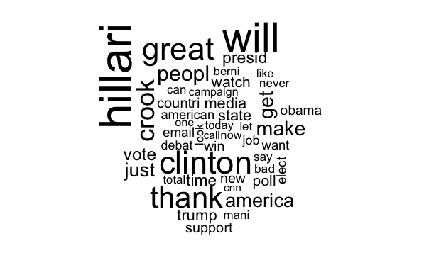

Wordcloud for High Retweet Trump Tweets

## Plot a word cloud

[figure not shown]

Wordcloud for Low Retweet Trump Tweets

## Supervised machine learning with text data

- The purpose of all of these steps was to prepare us to build classifiers using **supervised machine learning** methods.
- Recall that supervised machine learning methods are based upon human classification of data.
- The overall goal of supervised machine learning methods is to minimize both the **variance** and **bias** of a classifier.
- In other words we want to produce a classifier that produces the **best** results according to an objective standard.

## Step back - Assessing the performance of classifiers

- Imagine that we built a classifier to figure out which tweets were likely to "go viral"
- Such a classifier can make two types of errors:
1. It can incorrectly classify a tweet as one that will "go viral" when it goes not go viral (false positive)
2. It can incorrectly classify a tweet as one that will "not go viral" when it does go viral. (false negative)

## Confusion matrix

Confusion Matrix for Trump's Tweets

| Ground Truth | Class. Viral | Class. Not Viral |
| --- | --- | --- |
| Viral | Correct | False (-) |
| Not Viral | False (+) | Correct |

- A means of displaying this information is in a "confusion matrix" as the one shown above.
- If you are writing a paper using a classifier, **always** include the confusion matrix.

## Sensitivity, specificity and accuracy

- Class specific performance is a very important aspect of classifiers.
- Ideally, you want to keep both **false negatives** and **false positives** as low as possible.

## Sensitivity, specificity and accuracy

- **Accuracy** - % of documents that are correctly classified: \[ \frac{\text{# docs correctly classified}}{\text{# of docs classified}} \]
- **Sensitivity** is the % of positives that are correctly identified: \[ \frac{\text{# of positives identified}}{\text{# of positives}} \]
- **Specificity** is the % of negatives that are correctly identified: \[ \frac{\text{# of negatives identified}}{\text{# of negatives}} \]

## Sensitivity, specificity and accuracy

- It is very easy to have very high accuracy rates and high (sensitivity/specificity) but a crappy classifier.
- Lesson from classifying violence in religious texts.

## Discriminative and Generative Classifiers (from Ng and Jordan (2002))

- **Generative classifiers**: learn a model of the joint probability \(p(x,y)\) using Bayes rule to calculate the posterior \(p(y|x)\) and then pick the most likley label \(y\). (eg). Naive Bayes, all Bayesian methods in general)
- **Discriminative classifiers**: model the posterior \(p(y|x)\) directly. (logistic regression, SVMs etc.)
- Ng and Jordan (2002) find that for most kinds of data generative classifiers almost always perform better than discriminative classifiers, despite the fact that they tend to have higher MSE.
- In my personal experience, the results have been mixed.

## Naive Bayes

\[ P(C = k|D) = \frac{P(D|C = k)P(C=k)}{P(D)} \]

- Given a document D, we want to figure out the probability of the document belonging to a class C.
- We can do this by using Bayes theorem to directly calculate class probabilities given the words in a document

## Bayesian statistics terminology

- Before we discuss the naive Bayes algorithm it's useful to know a little bit about the components of Bayes theorem.

\[P(C = k|D)\] - is known as the **posterior** \[P(D |C = k)\] - is known as the **likelihood** \[P(C = k)\] - is known as the **prior** \[P(D)\] - is known as the **marginal likelihood** or **evidence**.

## For continuous distributions this is simply a probability model

\[ \pi(C | D) = f_{D|C}(D|C)\pi(C) / \int_{\Theta} f_{D|C}(D|C)\pi(C) \]

## For discrete distributions this just comes down to multiplying probabilities

\[ P(C = k|D) = \frac{P(D|C = k)P(C=k)}{P(D)} \]

- \(D = \{w_{1},w_{2}, \cdots, w_{k}\}\)
- \(C = \{1,0\}\)

## Thus…

\[ P(C = 1|D) = \frac{P(w_{1} \cap w_{2} \cap \cdots \cap w_{k} | C = 1) P(C = 1)}{P(w_{1} \cap w_{2} \cap \cdots \cap w_{k})} \]

## Thus…

Likelihood: \[P(D|C = 1) = \prod_{i=1}^W P(w_{i}|C =1)\] Prior: \[P(C = 1)= \frac{\# D \in C_{1}}{\# D \in C_{1},C_{2}}\]

Marginal likelihood: \[ P(D) = \prod_{i=1}^W P(w_{i}) \]

## Assumptions

If we assume that the words are independent conditional on a document class then:

\[ P(C = 1|D) = \frac{[P(w_{1}|C=1)P(w_{2}|C=1)\cdots P(w_{k}| C = 1)] P(C = 1)}{P(w_{1})P(w_{2})\cdots P(w_{k})} \]

## Where

\[P(w_{i} | C = 1) = \frac{\# w_{i} \in C_{1}}{\# \mathbf{w} \in C_{1}}\] \[P(C = 1)= \frac{\# D \in C_{1}}{\# D \in C_{1},C_{2}}\] \[P(w_{i})= \frac{\# w_{i} \in C_{1},C_{2}}{\# \mathbf{w} \in C_{1},C_{2}}\]

## Classification

\[ \arg\max_{k} C_{k} = P(C = k)\prod_{i=1}^W P(w_{i}|C =k) \] - For classification purposes, we can ignore the marginal likelihood and assign classes based on likehood and the prior.

## Classification

- An alternative means of expessing this is if:

\[ P(C = k | D) > \frac{1}{k}\]

- Assign document to class *k*.

## Laplace Smoothing

- Words with zero probability can seriously damage the performance of the classifier.
- To correct this problem we implement a *Laplace smoother* to ensure that there are no zero probability words.
- This amounts to simply adding 1 to each count; eg)

\[P(w_{i} | C = 1) = \frac{(\# w_{i} \in C_{1}) + 1}{(\# \mathbf{w} \in C_{1}) + 1}\]

## Example: Tweet Sentiment

Recent Tweet from @POTUS: "We are going to reduce your taxes big league…I want to start that process so quickly…We've got to start the tax reductions."

- \(C = {+,-}\)
- \(N = 1000 tweets\)
- 500 \(+\) tweets, 500 \(-\) tweets

## Example: Tweet Sentiment

Cleaned Tweet: "reduc tax big league start proces quick start tax reduc."

- \(C = {+,-}\)
- \(N = 1000\) tweets
- 500 \(+\) tweets, 500 \(-\) tweets